# edfReader vignette

Jan Vis

3-3-2018

# 1. Introduction

## 1.1 EDF and BDF

The [European Data Format](http://www.edfplus.info) (EDF) is a simple and flexible format for exchange and storage of multichannel biological and physical signals. It was developed by a few European ‘medical’ engineers who first met at the 1987 international Sleep Congress in Copenhagen. See http://www.edfplus.info/

The original EDF specification has been expanded in several ways. EDF+ supports the addition of annotations and non-continuous recordings. The [BioSemi Data Format](http://www.biosemi.com/faq/file_format.htm) BDF format uses 24 bits per sample (in stead of the 16 bits per sample in EDF). And [BDF+](http://www.teuniz.net/edfbrowser/bdfplus%20format%20description.html) is an EDF+ like extension of BDF.

This packages supports full reading of all these variants.

Both EDF and BDF files consist of an header followed by the data records with one or more signals recorded, either ordinary signals or annotation signals.

This package follows this structure by providing two basic functions: readEdfHeader and readEdfSignals (see the help pages for details)

## 1.2 Sample files

The examples below are based on the following files:

- AFile an EDF+ file with a continuous recording of 2 ordinary signals, two annotation signals and a sub second start specification
- BFile a BDF+ file with a continuous recording of 11 ordinary signals and one annotation signal
- CFile an EDF+ file with a continuous recording of 11 ordinary signals and one annotation signal
- DFile an EDF+ file with a discontinuous recording of 11 ordinary signals and one annotation signal

The BFile, CFile and DFile are derived from the “test_generator_2” test files from http://www.teuniz.net/edf_bdf_testfiles. The AFile is derived from the “test_generator8” file received from Teunis van Beelen by private communications.

```r
libDir <- system.file ("extdata", package="edfReader")
AFile <- paste (libDir, '/edfAnnonC.edf', sep='') # a file with 2 annotation signals
BFile <- paste (libDir, '/bdfPlusC.bdf' , sep='') # a continuously recorded BDF file
CFile <- paste (libDir, '/edfPlusC.edf' , sep='') # a continuously recorded EDF file
DFile <- paste (libDir, '/edfPlusD.edf' , sep='') # a discontinuously recorded EDF file
```

# 2. EDF headers objects

## 2.1 Introduction

The readEdfHeader function returns a list of class ‘ebdfHeader’ with all the data from the EDF or BDF file header. Part of this list is a data frame of class ‘ebdfSHeader’ which contains the signal headers.

In this chapter and the next, the EDF data read by edfReader is explained by using the S3 print() and summary() functions. The summary() provides somewhat more information than the print() function. In general, print() doesn’t contain internal EDF/BDF file data (like, e.g. the EDF signal number). This type of data is displayed with a summary() only.

Both print() and summary() may be used with a maxRows and/or file parameter. ‘maxRows’ will limit the number of rows in tables, its defult value = 24. ‘file’ will redirect the output to the file specified.

## 2.2 The ebdfHeader

A file header can be read with readEdfHeader()

```r
require (edfReader)
AHdr  <- readEdfHeader (AFile)
BHdr  <- readEdfHeader (BFile)
CHdr  <- readEdfHeader (CFile)
DHdr  <- readEdfHeader (DFile)
```

Summaries of the header data can be shown with the S3 summary () and print() functions

```r
BHdr
```

```
## Patient              : X X X X
## RecordingId          : Startdate 10-DEC-2009 X X test_generator
## StartTime            : 2009-12-10 12:45:54
## Continuous recording : TRUE
## Labels               : squarewave, ramp, pulse, ECG, noise, sine 1 Hz, sine 8 Hz, sine 8.5 Hz, sine 15 Hz, sine 17 Hz, sine 50 Hz, BDF Annotations
```

```r
summary (AHdr)
```

```
## File name            : /private/var/folders/1f/54gr9w5x38scv165h74_l9_h0000gn/T/RtmprgX1zf/Rinstbd47e1d18c8/edfReader/extdata/edfAnnonC.edf
## File type            : EDF+
## Version              : 0
## Patient              : X X X X
## RecordingId          : Startdate 01-JAN-2000 X X X
## StartTime            : 2000-01-01 14:15:16.7
## Continuous recording : TRUE
## Recorded period      : 1.2 sec
## Ordinary signals     : 2
## Annotation signals   : 2
## Labels               : EDF Annotations, Channel 1, EDF Annotations, Channel 2
## R signal names       : EDF Annotations-1, Channel 1, EDF Annotations-2, Channel 2
## Note                 : duplicate label names
```

edfAnnonC.edf contains two annotation. These signals must have the same label. As edfReader names signals after their labels (see below), distinguished names are created by appending ‘-1’ and ‘-2’ to the labels.

NOTE Actually, the startTime fraction .7 is not read from the EDF+/BDF+ file header but from the first data record. For details, see the section “Samples, time and periods”.

## 2.3 The ebdfSHeader

The print() and summary() output for an ebdfSHeader is shown below.

```r
AHdr$sHeader
```

```
## Signal labels : EDF Annotations, Channel 1, EDF Annotations, Channel 2
## Signal names  : EDF Annotations-1, Channel 1, EDF Annotations-2, Channel 2
## Note          : Duplicate label names
```

```r
summary (CHdr$sHeader)
```

```
##     EDF label/name      transducer sample rate preFilter
##  signal                                   /sec
##       1 squarewave                         200
##       2 ramp                               200
##       3 pulse                              200
##       4 ECG                                200
##       5 noise                              200
##       6 sine 1 Hz                          200
##       7 sine 8 Hz                          200
##       8 sine 8.5 Hz                        200
##       9 sine 15 Hz                         200
##      10 sine 17 Hz                         200
##      11 sine 50 Hz                         200
##      12 EDF Annotations n.a.              n.a. n.a.
```

# 3. EDF signal objects

## 3.1 Introduction

The signals in an EDF or BDF file can be read with the readEdfSignals function.

The readEdfSignals function with simplify=FALSE returns a list of class ‘ebdfSignals’ with the signals selected from the EDF / BDF file.

The signals in this list are of the following :

- continuous signals  
  of class ‘ebdfCSignal’ which may be from all types of EDF(+C)/BDF(+C) files
- fragmented signals  
  of class ‘ebdfFSignal’ which may be from EDF+D and BDF+D files only
- annotation signals  
  of class ‘ebdfASignal’ which may be from all types of EDF+ and BDF+ files.

## 3.2 Reading the whole recording of all signals

### 3.2.1 Reading a file with continuously recorded signals

```r
ASignals <- readEdfSignals (AHdr)
summary (ASignals)
```

```
## Start time            : 2000-01-01 14:15:16.7
## Ordinary signals:
##  Continuous recording : TRUE
##  Recorded period      : 1.2 sec
##  Period read          : whole recording
##  Signals
##  R      EDF    name/label transducer sampleRate preFilter samples
##  signal signal                             /sec
##  2      2      Channel 1                  30000             36000
##  3      4      Channel 2                  20000             24000
## Annotation signal:
##  R signal             : 1
##  EDF signal           : 1, 3
##  Name / label         : EDF Annotations
##  Period read          : whole recording
##  Record start specs   : 0
##  Annotations          : 8
##  First onset          : 0.049 sec
##  Last onset           : 1.19 sec
##  Last end             : 1.167 sec
```

NOTE 1 In case there is only one ordinary signal or annotation signal the data is displays in a number lines (see the annotation signal), if not, a table is used (see the ordinary signals).

NOTE 2 The EDF signal number ‘1, 3’ indicates that the annotation object contains the annotations from both the EDF signals 1 and 3. This can be prevented by using the ‘mergeASignals=FALSE’ option.

NOTE 3 Because of the merging of the annotation signals, the R signal numbers differ from the EDF signal numbers.

NOTE 4 ‘Last end’ equals the maximum of the annotations onsets + durations (see the section ‘annotation data’ below).

### 3.2.2 Reading a file with discontinuously recorded signals as a single signal

```r
DSignals <- readEdfSignals (DHdr)
DSignals
```

```
## Start time            : 2009-12-10 12:44:02
## Ordinary signals:
##  Continuous recording : FALSE
##  Recorded period      : 11 sec
##  Total period         : 20 sec
##  Period read          : whole recording
##  Signals
##  R      name        transducer sampleRate preFilter signalLength samples
##  signal                              /sec
##  1      squarewave                    200                   4000    2200
##  2      ramp                          200                   4000    2200
##  3      pulse                         200                   4000    2200
##  4      ECG                           200                   4000    2200
##  5      noise                         200                   4000    2200
##  6      sine 1 Hz                     200                   4000    2200
##  7      sine 8 Hz                     200                   4000    2200
##  8      sine 8.5 Hz                   200                   4000    2200
##  9      sine 15 Hz                    200                   4000    2200
##  10     sine 17 Hz                    200                   4000    2200
##  11     sine 50 Hz                    200                   4000    2200
## Annotation signal:
##  R signal             : 12
##  Name                 : EDF Annotations
##  Period read          : whole recording
##  Annotations          : 1
##  First onset          : 0 sec
##  Last onset           : 0 sec
##  Last end             : NA
```

NOTE 1 By default all fragments in a discontinuously recorded signals will be concatenated into one signal with the gaps filled with NA values. This can be prevented by using the ‘fragments=TRUE’ option.

NOTE 2 The number of NAs equals the signal length minus the number of samples.

NOTE 3 As the duration was not specified in the EDF file, the value of ‘Last end’ equals NA (see the section ‘annotation data’ below).

### 3.2.3 Reading a file with discontinuously recorded signals as a list of fragments

```r
DSignalsF <- readEdfSignals (DHdr, fragments = TRUE)
summary (DSignalsF)
```

```
## Start time            : 2009-12-10 12:44:02
## Ordinary signals:
##  Continuous recording : FALSE
##  Recorded period      : 11 sec
##  Total period         : 20 sec
##  Period read          : whole recording
##  Fragments per signal : 6
##  Signals
##  R/EDF  name/label  transducer sampleRate preFilter samples
##  signal                              /sec
##  1      squarewave                    200              2200
##  2      ramp                          200              2200
##  3      pulse                         200              2200
##  4      ECG                           200              2200
##  5      noise                         200              2200
##  6      sine 1 Hz                     200              2200
##  7      sine 8 Hz                     200              2200
##  8      sine 8.5 Hz                   200              2200
##  9      sine 15 Hz                    200              2200
##  10     sine 17 Hz                    200              2200
##  11     sine 50 Hz                    200              2200
## Annotation signal:
##  R / EDF signal       : 12
##  Name / label         : EDF Annotations
##  Period read          : whole recording
##  Record start specs   : 0
##  Annotations          : 1
##  First onset          : 0 sec
##  Last onset           : 0 sec
##  Last end             : NA
```

NOTE As a fragment doesn’t contain NAs there is no need for a ‘signal length’ column in the table. In stead the number of fragments per signal is provided.

## 3.3 Reading a selection of signals

The reading of signals can be restricted to a specific set by using the signals parameter. Signals can be identified by their EDF signal number, label, name, or signal type (‘Ordinary’ or ‘Annotations’). Also, the list may contain duplicates. The following 3 designations refer e.g. to the same signal.

```r
CSignals8 <- readEdfSignals (CHdr, signals=c(8, "8", "sine 8.5 Hz"))
summary (CSignals8)
```

```
##  R signal             : 1
##  EDF signal           : 8
##  Name / label         : sine 8.5 Hz
##  Start time           : 2009-12-10 12:44:02
##  Continuous recording : TRUE
##  Recorded period      : 20 sec
##  Period read          : whole recording
##  Sample rate          : 200 /sec
##  Transducer           :
##  Range                : -1000 : 1000 uV
##  Prefilter            :
##  Bits per sample      : 16
##  Number of samples    : 4000
## Signal summary
##    Min.   1st Qu.  Median    Mean   3rd Qu.  Max.
##  -99.9619 -70.695 0.015259 0.015259 70.7256 99.9924
```

NOTE As in this case only one signal has been read, the list of one signal was simplified to a single ‘ebdfCSignal’ object with R signal number 1. This could be prevented by using the ‘simplify=FALSE’ parameter.

EXAMPLE readEdfSignals (CHdr, signals=7, simplify=FALSE)[[1]] and readEdfSignals (CHdr, signals=7) will return the same object.

## 3.4 Reading a selected period

If required the reading can be restricted to a particular period. A period is identified with the ‘from’ and ‘till’ parameters which specify a time in seconds relative to the start of the recording.

```r
ASignalsPeriod    <- readEdfSignals (AHdr, from=0.7, till=1.8)
summary (ASignalsPeriod)
```

```
## Start time            : 2000-01-01 14:15:16.7
## Ordinary signals:
##  Continuous recording : TRUE
##  Recorded period      : 1.2 sec
##  Period read          : 0.5 sec
##    from               : 0.7 sec
##    till               : end
##  Signals
##  R      EDF    name/label transducer sampleRate preFilter samples
##  signal signal                             /sec
##  2      2      Channel 1                  30000             15000
##  3      4      Channel 2                  20000             10000
## Annotation signal:
##  R signal             : 1
##  EDF signal           : 1, 3
##  Name / label         : EDF Annotations
##  Annotation read if:
##    end from           : 0.7 sec
##    onset till         : 1.8 sec
##  Record start specs   : 0
##  Annotations          : 4
##  First onset          : 1.019 sec
##  Last onset           : 1.19 sec
##  Last end             : 1.167 sec
```

NOTE 1 Because the recorded period is only 1.2 sec (see above or use summary(ASignalsPeriod)), the period read for ordinary signals will not be [0.7, 1.8) but only [0.7, 1.2).

NOTE 2 For time and rounding details see the section “Samples, time and periods”

NOTE 3 The annotations included are those for which the period [onset, onset+duration] overlaps with the [from, till] period (see the section ‘annotation data’ below).

## 3.5 Ordinary signals, continuously recorded

```r
CSignals <- readEdfSignals (CHdr)
summary (CSignals$pulse)         # edfReader names signals after their label
```

```
##  R / EDF signal       : 3
##  Name / label         : pulse
##  Start time           : 2009-12-10 12:44:02
##  Continuous recording : TRUE
##  Recorded period      : 20 sec
##  Period read          : whole recording
##  Sample rate          : 200 /sec
##  Transducer           :
##  Range                : -1000 : 1000 uV
##  Prefilter            :
##  Bits per sample      : 16
##  Number of samples    : 4000
## Signal summary
##    Min.   1st Qu.   Median   Mean  3rd Qu.   Max.
##  0.015259 0.015259 0.015259 2.0148 0.015259 99.9924
```

## 3.6 Ordinary signals, not continuously recorded

Ordinary signals that are not continuously recorded can be read in two different ways:

- as a ‘continuous’ sequence of samples with ‘NA’ values filling the gaps (use ‘fragments=FALSE’, the default).  
  The result is of class ‘ebdfCSignal’ (the same as for a continuously recorded signal).
- as a number fragments of continuously recorded parts (use ‘fragments=TRUE’)  
  The result is of class ‘ebdfFSignal’.

The latter method will use a more complex data structure, the first may result in a (much too) huge object.

```r
CDSignals <- readEdfSignals (DHdr, from=5.1, till=18)
FDSignals <- readEdfSignals (DHdr, fragments=TRUE)
```

The objects of class ‘ebdfCSignal’ are printed and summarised in the same way as continuously recorded signals.

```r
summary (FDSignals$`sine 8.5 Hz`)         # note the "`" quotes for a name with spaces.
```

```
##  R / EDF signal       : 8
##  Name / label         : sine 8.5 Hz
##  Start time           : 2009-12-10 12:44:02
##  Continuous recording : FALSE
##  Recorded period      : 11 sec
##  Total period         : 20 sec
##  Period read          : whole recording
##  Sample rate          : 200 /sec
##  Transducer           :
##  Range                : -1000 : 1000 uV
##  Prefilter            :
##  Bits per sample      : 16
##  Number of fragments  : 6
## Fragments summaries
##  fragment   Min.   1st Qu.   Median     Mean    3rd Qu.  Max.
##         1 -99.8703 -65.2171  9.41482   3.73816  71.8242 99.9924
##         2 -99.8703 -65.2171  9.41482   3.73816  71.8242 99.9924
##         3 -99.9619 -70.695   0.015259  0.015259 70.7256 99.9924
##         4 -99.8703 -65.2171  9.41482   3.73816  71.8242 99.9924
##         5 -99.9619 -71.7937 -9.3843   -3.70764  65.2476 99.9008
##         6 -99.9619 -71.7937 -9.3843   -3.70764  65.2476 99.9008
## Whole recording
##    Min.   1st Qu.  Median    Mean   3rd Qu.  Max.
##  -99.9619 -70.695 0.015259 0.353704 70.7256 99.9924
```

## 3.7 Annotation signals

```r
CSignals$`EDF Annotations`
```

```
##  R signal    : 12
##  Name        : EDF Annotations
##  Start time  : 2009-12-10 12:44:02
##  Period read : whole recording
##  Annotations : 2
##  First onset : 0 sec
##  Last onset  : 600 sec = 00:10:00 h:m:s
##  Last end    : NA
```

NOTE “= … h:m:s” is added to a time value if that value is greater than 300 seconds.

[output not shown]

NOTE 1 Because both annotation signals are merged into one, the merged signal is named `EDF Annotations` again.

NOTE 2 The “Record start specs = 0” indicates that the record start specifications are not included, i.e. readEdfSignals was used with the parameter recordStartTimes = FALSE.

# 4. Samples, time and periods

## 4.1 The start time

In case of an EDF or BDF file, the startTime attribute is based on the startdate and starttime in the EDF/BDF header.

The starttime in an EDF/BDF header is specified up to the second.

In EDF+ and BDT+ files a sub second start time can be specified as the start time of the first data record. See the last paragraph in section 2.2.4 of the EDF+ specification.

See, e.g., the startTime for the AFile:

```r
format (AHdr$startTime, format="%Y-%m-%d %H:%M:%OS3",  usetz = FALSE)
```

```
## [1] "2000-01-01 14:15:16.700"
```

For EDF+/BDF+ files, the startTime shown by the edfReader is based on both the data in the header and the EDF+/BDF+ start time of the first data record, i.e. on the actual start of the recording. As a consequence the R start time of this first data record is always 0.

```r
ASignalsPlusStartTimes <- readEdfSignals(AHdr, signals='EDF Annotations-1', recordStarts=TRUE)
ASignalsPlusStartTimes$recordStartTimes$startTime[1]
```

```
## [1] 0
```

By the same token, the onset for annotations is relative to this R startTime (in an EDF+/BDF+ file the onset is relative to the startdate and starttime in the EDF/BDF header).

## 4.2 Samples and time

As usual, a recording starts at time 0 (relative to the recording startTime) and with sample 1.

Consequently sample n will be at time (n-1)/sRate, where sRate denotes the sample rate.

## 4.3 Samples and periods

Apart from rounding errors, a from - till period in readEdfSignals will be the period [from,till), i.e. starting at from and up to be but not including till.

This may sound strange, but this convention has the following properties:

- the sample rate can be defined as the total number of samples divided by the total time
- or, more precise, any period which is a multiple of the sample period sPeriod will always contain the same number of samples  
  i.e. for any t ≥ 0, [t, t+n*sPeriod) will always contain n samples
- for any number of adjacent periods, the total number of samples will be always the sum of the samples in the individual periods.
- the first sample will be ceiling(from*sRate) + 1
- the last sample will be ceiling(till*sRate)
- with from=t and till=t, the empty set [t,t) corresponds to [ceiling(t*sRate) + 1, ceiling(t*sRate)] which is also empty.

## 4.4 Alignment

### 4.4.1 The issue

In an EDF+/BDF+ file the start of the recording of the signals in a data record is specified in its first annotations signal. For a +D file the recording in a subsequent data record may start at any time after the start of the previous data record plus the record duration time.

However, the gap between to +D file data records may not be an exact multiple of the sample period of its signals. This raises a question about the alignment of samples in these subsequent data records.

### 4.4.2 Two basic models.

The alignment of ordinary signals can be modelled in two different ways:

1. with a interrupted clock  
   In which case the first sample for every recorded signal is taken at the start of the recording for that data record
2. which a continuously running clock  
   In which case the clock starts at the start of the first record and all sampling is based on the individual signal sample rate(s). In other words, the sample time for a signal sample in the data records is aligned to its sample rate.

It should be noted that the model with the continuously running clock is (implicitly) required if one want to map all fragments of a signal into a single single (with NA values in the gap) one.

The edfReader supports both models, for any fragment it provides both the aligned data according to the “continuously running clock” model as well as the record start time from the data record.

### 4.4.3 Alignment details

The first sample in every +D record can be aligned as follows:

```
n = ceiling (sRate * recordStartTime) + 1
```

and the

```
sampleTime = (n - 1) / sRate
```

Where

- sRate is the sample rate
- n is the sample number when continuously sampled from the start of the recording
- recordStartTime denotes the start of the record relative to the start of the recording
- sampleTime the (aligned) sample time for the n’s sample

However, in order to avoid rounding unnecessary rounding errors the first formula is actually implemented as follows:

```
n = ceiling (sRate * (recordStartTime - 2 * distanceToNextLowerNumeric)) + 1
```

Where distanceToNextLowerNumeric = the distance between recordStartTime and its next lower numeric (double float) value.

NOTE In earlier edfReader versions the margin was 5 * .Machine$double.eps. And .Machine$double.eps equals the distanceToNextLowerNumeric if x == 2. See e.g. https://en.wikipedia.org/wiki/Machine_epsilon for details.

## 4.5 Parameters involved

For any signal object and any fragment:

- the ‘start’ parameter contains the aligned signal / fragment start time in seconds, relative to the start in the recording (for a signal it is always 0)
- the ‘fromSample’ parameter contains the sample number for the corresponding sample
- the ‘recordingStart’ parameter contains the start of the recording for the data record. For a ‘+’ file this is the time specified in the first annotation signal
- a ‘from’ parameter in an readEdfSignals invocation is relative to the start of the recording. The default value is 0
- a ‘till’ parameter in an readEdfSignals invocation is relative to the start of the recording. The default value is Inf
- a ‘recordedPeriod’ parameter equals the number of data records times the record duration time as specified in the header
- a totalPeriod parameter contains the period from the start time in the header till the end of the recording of the ordinary signals, i.e. the record start time of the last data record plus the record duration time

# 5. Object details

## 5.1 Introduction

In this chapter the strucnture of the R EDF/BDF objects is explained by using the str(), or more often, the str1() function as defined below.

```r
str1 <- function (x) str (x, max.level = 1)
```

NOTE The str() function may round numeric and POSIXct values !

## 5.2 Header details

### 5.2.1 Header attributes

The header data encompass the following:

```r
str1 (CHdr)
```

```
## List of 17
##  $ fileName           : chr "/private/var/folders/1f/54gr9w5x38scv165h74_l9_h0000gn/T/RtmprgX1zf/Rinstbd47e1d18c8/edfReader/extdata/edfPlusC.edf"
##  $ fileType           : chr "EDF"
##  $ version            : chr "0"
##  $ patient            : chr "X X X X"
##  $ recordingId        : chr "Startdate 10-DEC-2009 X X test_generator"
##  $ startTime          : POSIXct[1:1], format: "2009-12-10 12:44:02"
##  $ startSecondFraction: num 0
##  $ headerLength       : int 3328
##  $ reserved           : chr "EDF+C"
##  $ nRecords           : int 20
##  $ recordDuration     : num 1
##  $ nSignals           : int 12
##  $ recordedPeriod     : num 20
##  $ sampleBits         : num 16
##  $ isPlus             : logi TRUE
##  $ isContinuous       : logi TRUE
##  $ sHeaders           :Classes 'ebdfSHeaders' and 'data.frame':  12 obs. of  15 variables:
##  - attr(*, "class")= chr "ebdfHeader"
```

The fields version, patient, recordingId, startTime, headerLength, reserved, nRecords, recordDuration, and nSignals are from the file header.

the startSecondFraction attribute contains the sub second start data specified in the first data record. See the ‘The start time’ section above.

sHeaders is detailed below. The others attributes are derived ones.

### 5.2.2 Signal header attributes

The signal header data encompass the following:

```r
str1 (CHdr$sHeader)
```

```
## Classes 'ebdfSHeaders' and 'data.frame': 12 obs. of  15 variables:
##  $ label           : chr  "squarewave" "ramp" "pulse" "ECG" ...
##  $ transducerType  : chr  "" "" "" "" ...
##  $ physicalDim     : chr  "uV" "uV" "uV" "uV" ...
##  $ physicalMin     : num  -1000 -1000 -1000 -1000 -1000 -1000 -1000 -1000 -1000 -1000 ...
##  $ physicalMax     : num  1000 1000 1000 1000 1000 1000 1000 1000 1000 1000 ...
##  $ digitalMin      : int  -32768 -32768 -32768 -32768 -32768 -32768 -32768 -32768 -32768 -32768 ...
##  $ digitalMax      : int  32767 32767 32767 32767 32767 32767 32767 32767 32767 32767 ...
##  $ preFilter       : chr  "" "" "" "" ...
##  $ samplesPerRecord: int  200 200 200 200 200 200 200 200 200 200 ...
##  $ reserved        : chr  "" "" "" "" ...
##  $ gain            : num  0.0305 0.0305 0.0305 0.0305 0.0305 ...
##  $ offset          : num  0.0153 0.0153 0.0153 0.0153 0.0153 ...
##  $ sRate           : num  200 200 200 200 200 200 200 200 200 200 ...
##  $ isAnnotation    : logi  FALSE FALSE FALSE FALSE FALSE FALSE ...
##  $ sLength         : int  4000 4000 4000 4000 4000 4000 4000 4000 4000 4000 ...
```

The fields label, transducerType, physicalDim, physicalMin, physicalMax, digitalMin, digitalMax, preFilter, samplesPerRecord, and reserved are from the file header. The others are derived. Gain and offset are used to map the digital sample values to the range of physical values.

For annotation signals the only relevant fields are “label” which must have the value “EDF Annotations” (or “BDF Annotations”) and “samplesPerRecord”.

## 5.3 Signal details

### 5.3.1 Ordinary signal objects of class ‘ebdfCSignal’

The data for ordinary signal objects of class ‘ebdfCSignal’ encompass the following:

```r
str1 (CSignals$pulse)
```

```
## List of 19
##  $ signal        : num [1:4000] 99.9924 99.9924 99.9924 99.9924 0.0153 ...
##  $ startTime     : POSIXct[1:1], format: "2009-12-10 12:44:02"
##  $ signalNumber  : int 3
##  $ RSignalNumber : int 3
##  $ label         : chr "pulse"
##  $ name          : chr "pulse"
##  $ isContinuous  : logi TRUE
##  $ isAnnotation  : logi FALSE
##  $ recordedPeriod: num 20
##  $ totalPeriod   : num 20
##  $ from          : num 0
##  $ till          : num Inf
##  $ start         : num 0
##  $ fromSample    : num 1
##  $ transducerType: chr ""
##  $ sampleBits    : num 16
##  $ sRate         : num 200
##  $ range         : chr "-1000 : 1000 uV"
##  $ preFilter     : chr ""
##  - attr(*, "class")= chr "ebdfCSignal"
```

The attributes startTime, signalNumber, label, isContinuous, isAnnotation, recordedPeriod, totalPeriod, transducerType, sampleBits, sRate, range, and preFilter are (derived) from the header data.

The signalNumber denotes the EDF signal number, i.e. the signal number in the EDF/BDF file. The RSignalNumber denotes the number / index in the R list of signals read.

For a continuously recorded signal the totalPeriod is equal to the recordedPeriod. For a not continuously recorded signal the total period equals the start of the last data record plus its duration.

The attributes from and till contain the values of the corresponding actual readEdfSignals parameters. The default values are 0 and Inf.

The start attribute contains the start time and is always zero. The fromSample attribute contains the first sample number and is always 1. By including these attributes, signals and fragments share the same time/sample attributes.

The signal attribute contains the sample data from the EDF / BDF data records. If read with the readEdfSignals parameter physical=TRUE, the default, the digital sample values are mapped to physical values. With physical=FALSE, signals contains the digital sample values.

The physical values are calculated as follows:  
physicalValue = gain * digitalValue + offset,  
with: gain = (physicalMax - physicalMin) / (digitalMax - digitalMin)  
offset = physicalMax - gain * digitalMax

### 5.3.2 Ordinary signal objects of class ‘ebdfFSignal’

#### 5.3.2.1 The fragmented signal

The data for ordinary signal objects of class ‘ebdfFSignal’ encompass the following:

```r
str1 (FDSignals$`sine 8.5 Hz`)
```

```
## List of 20
##  $ startTime     : POSIXct[1:1], format: "2009-12-10 12:44:02"
##  $ signalNumber  : int 8
##  $ RSignalNumber : int 8
##  $ label         : chr "sine 8.5 Hz"
##  $ name          : chr "sine 8.5 Hz"
##  $ isContinuous  : logi FALSE
##  $ isAnnotation  : logi FALSE
##  $ recordedPeriod: num 11
##  $ totalPeriod   : num 20
##  $ from          : num 0
##  $ till          : num Inf
##  $ start         : num 0
##  $ fromSample    : num 1
##  $ transducerType: chr ""
##  $ sampleBits    : num 16
##  $ sRate         : num 200
##  $ range         : chr "-1000 : 1000 uV"
##  $ preFilter     : chr ""
##  $ fragments     :List of 6
##  $ nSamples      : int 2200
##  - attr(*, "class")= chr "ebdfFSignal"
```

For the attributes startTime, signalNumber, label, isContinuous, isAnnotation, recordedPeriod, totalPeriod, from, till, start, fromSample, transducerType, sampleBits, sRate, range and preFilter see the previous section.

For a not continuously recorded signal the total period equals the start of the last data record plus its duration.

The fragments attribute contains the list of recorded fragments.

### 5.3.2.2 The fragments

The data of a signal fragment in objects of class ‘ebdfFSignal’ encompass the following:

```r
str1 (FDSignals$`sine 8.5 Hz`$fragments[[1]])
```

```
## List of 4
##  $ start         : num 0
##  $ fromSample    : num 1
##  $ recordingStart: num 0
##  $ signal        : num [1:200] 26.4 50.9 71.8 87.6 97.2 ...
```

The fromSample attribute contains the sample number of the first sample in this fragment (as if it were a continuous recording). The start attribute the sample time for this sample.

The recordingStart attribute contains the start of the recording as specified in the data racored (minus the start time of the first data record, see the section ‘The start time’).

The ‘signal’ attribute contains the fragment’s sample values. These may be physical values (the default) or digital values (see above).

### 5.3.3 Annotation signals

#### 5.3.3.1 The annoration signal

The data for annotation signal objects of class ‘ebdfASignal’ encompass the following:

```r
ASignals2 <- readEdfSignals (AHdr, recordStarts=TRUE)
str1 (ASignals2$`EDF Annotations`)
```

```
## List of 15
##  $ startTime       : POSIXct[1:1], format: "2000-01-01 14:15:16"
##  $ signalNumber    : int [1:2] 1 3
##  $ RSignalNumber   : int 1
##  $ label           : chr "EDF Annotations"
##  $ name            : chr "EDF Annotations"
##  $ isContinuous    : logi TRUE
##  $ isAnnotation    : logi TRUE
##  $ totalPeriod     : num 1.2
##  $ from            : num 0
##  $ till            : num Inf
##  $ annotations     :'data.frame':    8 obs. of  6 variables:
##  $ recordStartTimes:'data.frame':    12 obs. of  2 variables:
##  $ annotsFrom      : num 0.049
##  $ lastOnset       : num 1.19
##  $ lastEnd         : num 1.17
##  - attr(*, "class")= chr "ebdfASignal"
```

For the attributes startTime, signalNumber, label, isContinuous, isAnnotation, totalPeriod, from, and till see the section for objects of class ‘ebdfCSignal’.

The annotations attribute contains a data frame with the individual annotations.

NOTE The POSIXct startTime has been rounded by str().

### 5.3.3.2 The annotations

The data for a single annotation encompass the following:

```r
str1 (ASignals2$`EDF Annotations`$annotations)
```

```
## 'data.frame':    8 obs. of  6 variables:
##  $ record    : int  1 2 2 2 11 12 12 12
##  $ onset     : num  0.049 0.1 0.14 0.172 1.019 ...
##  $ duration  : num  NA NA NA 0.005 NA NA 0.005 NA
##  $ annotation: chr  "Test1" "Test2" "Test3" "Test4" ...
##  $ end       : num  NA NA NA 0.177 NA ...
##  $ fromSignal: int  3 1 1 1 3 1 1 1
```

The record attribute refers to the data record the annotation was read from.

The onset attribute contains the time of the annotation relative to the start of the recording.

The duration attribute contains the duration of the annotated event. The duration may not be specified in the EDF/BDF file.

The annotation attribute contains the annotation associated with the onset and duration.

The end attribute equals the sum of the onset plus the duration.

The fromSignal attribute, if present, refers to the signal that contains the annotation. This attributed is present only if the annotations from different signals were merged into one ‘ebdfASignal’ object.

NOTE In case readEdfSignals is used with a from and till parameter only those annotatins are included for which the onset is within the [from, till] interval or - in case the duration is specified - the periodd [onset, onset+duration] overlaps with this interval.

### 5.3.3.3 The record start times

In an EDF+/BDF+ file the start of the recording of a data recorded is specified in the (first) annotation signal. When read with recordStarts=TRUE, these start times are included in the recordStartTimes data frame.

```r
str1 (ASignals2$`EDF Annotations`$recordStartTimes)
```

```
## 'data.frame':    12 obs. of  2 variables:
##  $ record   : int  1 2 3 4 5 6 7 8 9 10 ...
##  $ startTime: num  0 0.1 0.2 0.3 0.4 0.5 0.6 0.7 0.8 0.9 ...
```

NOTE The startTime is relative to the R startTime, i.e. the start of the recording. (in an EDF+/BDF+ file the onset is relative to the startdate and starttime in the EDF+/BDF+ header).

# 6. Next step: a quick look

One of the the first things you may want to do with the imported signals is to have look at them.

This can be achieved with one of the several plot packages available, e.g.:

```
- ‘plot’ (included in the base installation)

- ‘lattice', or

- 'ggplot2'
```

As an example, the function plotEdfSignals() uses ggplot2 and will plot one or more signals  
over some period of time. The plot shown presents the period from 0.2 till 0.5 seconds of the ‘sine 8.5 Hz’ and the ‘sine 50 Hz’ signals in CSignals.

```
##  totLength= 120 | from-1= 120
```

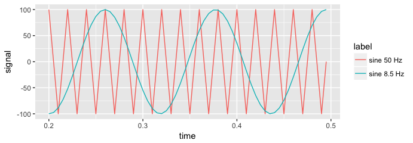

```r
plotEdfSignals <- function (signals,labels, from=0, till=Inf) {
    nLabels <- length (labels)
    sRate   <- numeric (length = nLabels)
    fromS   <- integer (length = nLabels)
    tillS   <- integer (length = nLabels)
    sLength <- integer (length = nLabels)
    for (i in 1:nLabels) {
        sRate[i]    <- signals[[labels[i]]]$sRate
        fromS[i]    <- ceiling (sRate[i] * max (from, 0)) +1
        tillS[i]    <- ceiling (sRate[i] * till)
        tillS[i]    <- min (tillS[i], length(signals[[labels[i]]]$signal))
        sLength[i]  <- tillS[i] - fromS[i] + 1
    }
    totLength  <- sum (sLength)
    cat (" totLength=",  totLength)
    time    <- numeric   (length = totLength)
    signal  <- numeric   (length = totLength)
    label   <- character (length = totLength)
    from <- 1
    for (i in 1:nLabels) {
        till <- from + sLength[i] - 1
        time  [from:till]   <- seq (from=fromS[i]-1, to=(tillS[i]-1)) / sRate[i]
        signal[from:till]   <- signals[[labels[i]]]$signal[fromS[i]:tillS[i]]
        label [from:till]   <- rep(labels[i], sLength[i])
        from <- till + 1
    }
    cat (" | from-1=", from-1,'\n')

    ggplotDF <- data.frame (time=time, signal=signal, label=label)
    ggplot (ggplotDF, aes(x=time, y=signal, colour=label)) + geom_line()
}

if (require(ggplot2)) {
    CSignals <- readEdfSignals (CHdr)
    plotEdfSignals (CSignals, labels=c('sine 8.5 Hz', 'sine 50 Hz'), from=.2, till=0.5)
}
```

For details about ggplot2 see e.g. the ‘R Graphics cookbook’

Enjoy.

# 7. Acknowledgement

This package has used code from

- edf.R version 0.3 (27-11-2013) from Fabien Feschet
- the work of Henelius Andreas as of July 2015,  
  https://github.com/bwrc/edf

# 8. References

1. Specification of EDF  
   http://www.edfplus.info/specs/edf.html
2. Specification of EDF+  
   http://www.edfplus.info/specs/edfplus.html
3. Specification of BDF  
   see ‘Which file format does BioSemi use’ at  
   http://www.biosemi.com/faq/file_format.htm
4. Specification of BDF+  
   http://www.teuniz.net/edfbrowser/bdfplus%20format%20description.html

Other useful EDF related sources can be found at:  
http://www.edfplus.info/downloads/